# Risk Factor Analysis

## Outcome Variable

**Outcome Variable:** stunted

## Predictor Variables

**Intervention Variable:** mwtkg

**Adjustment Set:**

unadjusted

## Stratifying Variables

The analysis was stratified on these variable(s):

- agecat
- studyid
- country

## Data Summary

| agecat | studyid | country | A | n | nA | nAY0 | nAY1 |
| --- | --- | --- | --- | --- | --- | --- | --- |
| Birth | ki0047075b-MAL-ED | BANGLADESH | >=57.5 | 246 | 50 | 43 | 7 |
| Birth | ki0047075b-MAL-ED | BANGLADESH | <42.5 | 246 | 53 | 44 | 9 |
| Birth | ki0047075b-MAL-ED | BANGLADESH | [42.5-50) | 246 | 85 | 68 | 17 |
| Birth | ki0047075b-MAL-ED | BANGLADESH | [50-57.5) | 246 | 58 | 49 | 9 |
| Birth | ki0047075b-MAL-ED | BRAZIL | >=57.5 | 184 | 122 | 111 | 11 |
| Birth | ki0047075b-MAL-ED | BRAZIL | <42.5 | 184 | 12 | 9 | 3 |
| Birth | ki0047075b-MAL-ED | BRAZIL | [42.5-50) | 184 | 13 | 11 | 2 |
| Birth | ki0047075b-MAL-ED | BRAZIL | [50-57.5) | 184 | 37 | 34 | 3 |
| Birth | ki0047075b-MAL-ED | INDIA | >=57.5 | 198 | 37 | 34 | 3 |
| Birth | ki0047075b-MAL-ED | INDIA | <42.5 | 198 | 34 | 25 | 9 |
| Birth | ki0047075b-MAL-ED | INDIA | [42.5-50) | 198 | 67 | 56 | 11 |
| Birth | ki0047075b-MAL-ED | INDIA | [50-57.5) | 198 | 60 | 51 | 9 |
| Birth | ki0047075b-MAL-ED | NEPAL | >=57.5 | 172 | 63 | 56 | 7 |
| Birth | ki0047075b-MAL-ED | NEPAL | <42.5 | 172 | 2 | 2 | 0 |
| Birth | ki0047075b-MAL-ED | NEPAL | [42.5-50) | 172 | 30 | 24 | 6 |
| Birth | ki0047075b-MAL-ED | NEPAL | [50-57.5) | 172 | 77 | 72 | 5 |
| Birth | ki0047075b-MAL-ED | PERU | >=57.5 | 276 | 99 | 91 | 8 |
| Birth | ki0047075b-MAL-ED | PERU | <42.5 | 276 | 13 | 9 | 4 |
| Birth | ki0047075b-MAL-ED | PERU | [42.5-50) | 276 | 52 | 42 | 10 |
| Birth | ki0047075b-MAL-ED | PERU | [50-57.5) | 276 | 112 | 101 | 11 |
| Birth | ki0047075b-MAL-ED | SOUTH AFRICA | >=57.5 | 228 | 166 | 152 | 14 |
| Birth | ki0047075b-MAL-ED | SOUTH AFRICA | <42.5 | 228 | 2 | 2 | 0 |
| Birth | ki0047075b-MAL-ED | SOUTH AFRICA | [42.5-50) | 228 | 13 | 11 | 2 |
| Birth | ki0047075b-MAL-ED | SOUTH AFRICA | [50-57.5) | 228 | 47 | 40 | 7 |
| Birth | ki0047075b-MAL-ED | TANZANIA, UNITED REPUBLIC OF | >=57.5 | 121 | 56 | 51 | 5 |
| Birth | ki0047075b-MAL-ED | TANZANIA, UNITED REPUBLIC OF | <42.5 | 121 | 4 | 1 | 3 |
| Birth | ki0047075b-MAL-ED | TANZANIA, UNITED REPUBLIC OF | [42.5-50) | 121 | 28 | 24 | 4 |
| Birth | ki0047075b-MAL-ED | TANZANIA, UNITED REPUBLIC OF | [50-57.5) | 121 | 33 | 27 | 6 |
| Birth | ki1000304b-SAS-CompFeed | INDIA | >=57.5 | 69 | 3 | 2 | 1 |
| Birth | ki1000304b-SAS-CompFeed | INDIA | <42.5 | 69 | 20 | 12 | 8 |

[output cut: 378 more lines]

The following strata were considered:

- agecat: 12 months, studyid: ki0047075b-MAL-ED, country: BANGLADESH
- agecat: 12 months, studyid: ki0047075b-MAL-ED, country: BRAZIL
- agecat: 12 months, studyid: ki0047075b-MAL-ED, country: INDIA
- agecat: 12 months, studyid: ki0047075b-MAL-ED, country: NEPAL
- agecat: 12 months, studyid: ki0047075b-MAL-ED, country: PERU
- agecat: 12 months, studyid: ki0047075b-MAL-ED, country: SOUTH AFRICA
- agecat: 12 months, studyid: ki0047075b-MAL-ED, country: TANZANIA, UNITED REPUBLIC OF
- agecat: 12 months, studyid: ki1000304b-SAS-CompFeed, country: INDIA
- agecat: 12 months, studyid: ki1017093-NIH-Birth, country: BANGLADESH
- agecat: 12 months, studyid: ki1017093b-PROVIDE, country: BANGLADESH
- agecat: 12 months, studyid: ki1017093c-NIH-Crypto, country: BANGLADESH
- agecat: 12 months, studyid: ki1066203-TanzaniaChild2, country: TANZANIA, UNITED REPUBLIC OF
- agecat: 12 months, studyid: ki1119695-PROBIT, country: BELARUS
- agecat: 12 months, studyid: ki1126311-ZVITAMBO, country: ZIMBABWE
- agecat: 12 months, studyid: ki1148112-LCNI-5, country: MALAWI
- agecat: 18 months, studyid: ki0047075b-MAL-ED, country: BANGLADESH
- agecat: 18 months, studyid: ki0047075b-MAL-ED, country: BRAZIL
- agecat: 18 months, studyid: ki0047075b-MAL-ED, country: INDIA
- agecat: 18 months, studyid: ki0047075b-MAL-ED, country: NEPAL
- agecat: 18 months, studyid: ki0047075b-MAL-ED, country: PERU
- agecat: 18 months, studyid: ki0047075b-MAL-ED, country: SOUTH AFRICA
- agecat: 18 months, studyid: ki0047075b-MAL-ED, country: TANZANIA, UNITED REPUBLIC OF
- agecat: 18 months, studyid: ki1000304b-SAS-CompFeed, country: INDIA
- agecat: 18 months, studyid: ki1017093-NIH-Birth, country: BANGLADESH
- agecat: 18 months, studyid: ki1017093b-PROVIDE, country: BANGLADESH
- agecat: 18 months, studyid: ki1017093c-NIH-Crypto, country: BANGLADESH
- agecat: 18 months, studyid: ki1066203-TanzaniaChild2, country: TANZANIA, UNITED REPUBLIC OF
- agecat: 18 months, studyid: ki1112895-iLiNS-Zinc, country: BURKINA FASO
- agecat: 18 months, studyid: ki1119695-PROBIT, country: BELARUS
- agecat: 18 months, studyid: ki1126311-ZVITAMBO, country: ZIMBABWE
- agecat: 18 months, studyid: ki1148112-LCNI-5, country: MALAWI
- agecat: 24 months, studyid: ki0047075b-MAL-ED, country: BANGLADESH
- agecat: 24 months, studyid: ki0047075b-MAL-ED, country: BRAZIL
- agecat: 24 months, studyid: ki0047075b-MAL-ED, country: INDIA
- agecat: 24 months, studyid: ki0047075b-MAL-ED, country: NEPAL
- agecat: 24 months, studyid: ki0047075b-MAL-ED, country: PERU
- agecat: 24 months, studyid: ki0047075b-MAL-ED, country: SOUTH AFRICA
- agecat: 24 months, studyid: ki0047075b-MAL-ED, country: TANZANIA, UNITED REPUBLIC OF
- agecat: 24 months, studyid: ki1017093-NIH-Birth, country: BANGLADESH
- agecat: 24 months, studyid: ki1017093b-PROVIDE, country: BANGLADESH
- agecat: 24 months, studyid: ki1017093c-NIH-Crypto, country: BANGLADESH
- agecat: 24 months, studyid: ki1066203-TanzaniaChild2, country: TANZANIA, UNITED REPUBLIC OF
- agecat: 24 months, studyid: ki1119695-PROBIT, country: BELARUS
- agecat: 24 months, studyid: ki1126311-ZVITAMBO, country: ZIMBABWE
- agecat: 24 months, studyid: ki1148112-LCNI-5, country: MALAWI
- agecat: 3 months, studyid: ki0047075b-MAL-ED, country: BANGLADESH
- agecat: 3 months, studyid: ki0047075b-MAL-ED, country: BRAZIL
- agecat: 3 months, studyid: ki0047075b-MAL-ED, country: INDIA
- agecat: 3 months, studyid: ki0047075b-MAL-ED, country: NEPAL
- agecat: 3 months, studyid: ki0047075b-MAL-ED, country: PERU
- agecat: 3 months, studyid: ki0047075b-MAL-ED, country: SOUTH AFRICA
- agecat: 3 months, studyid: ki0047075b-MAL-ED, country: TANZANIA, UNITED REPUBLIC OF
- agecat: 3 months, studyid: ki1000304b-SAS-CompFeed, country: INDIA
- agecat: 3 months, studyid: ki1017093-NIH-Birth, country: BANGLADESH
- agecat: 3 months, studyid: ki1017093b-PROVIDE, country: BANGLADESH
- agecat: 3 months, studyid: ki1017093c-NIH-Crypto, country: BANGLADESH
- agecat: 3 months, studyid: ki1066203-TanzaniaChild2, country: TANZANIA, UNITED REPUBLIC OF
- agecat: 3 months, studyid: ki1119695-PROBIT, country: BELARUS
- agecat: 3 months, studyid: ki1126311-ZVITAMBO, country: ZIMBABWE
- agecat: 6 months, studyid: ki0047075b-MAL-ED, country: BANGLADESH
- agecat: 6 months, studyid: ki0047075b-MAL-ED, country: BRAZIL
- agecat: 6 months, studyid: ki0047075b-MAL-ED, country: INDIA
- agecat: 6 months, studyid: ki0047075b-MAL-ED, country: NEPAL
- agecat: 6 months, studyid: ki0047075b-MAL-ED, country: PERU
- agecat: 6 months, studyid: ki0047075b-MAL-ED, country: SOUTH AFRICA
- agecat: 6 months, studyid: ki0047075b-MAL-ED, country: TANZANIA, UNITED REPUBLIC OF
- agecat: 6 months, studyid: ki1000304b-SAS-CompFeed, country: INDIA
- agecat: 6 months, studyid: ki1017093-NIH-Birth, country: BANGLADESH
- agecat: 6 months, studyid: ki1017093b-PROVIDE, country: BANGLADESH
- agecat: 6 months, studyid: ki1017093c-NIH-Crypto, country: BANGLADESH
- agecat: 6 months, studyid: ki1066203-TanzaniaChild2, country: TANZANIA, UNITED REPUBLIC OF
- agecat: 6 months, studyid: ki1119695-PROBIT, country: BELARUS
- agecat: 6 months, studyid: ki1126311-ZVITAMBO, country: ZIMBABWE
- agecat: 6 months, studyid: ki1148112-LCNI-5, country: MALAWI
- agecat: 9 months, studyid: ki0047075b-MAL-ED, country: BANGLADESH
- agecat: 9 months, studyid: ki0047075b-MAL-ED, country: BRAZIL
- agecat: 9 months, studyid: ki0047075b-MAL-ED, country: INDIA
- agecat: 9 months, studyid: ki0047075b-MAL-ED, country: NEPAL
- agecat: 9 months, studyid: ki0047075b-MAL-ED, country: PERU
- agecat: 9 months, studyid: ki0047075b-MAL-ED, country: SOUTH AFRICA
- agecat: 9 months, studyid: ki0047075b-MAL-ED, country: TANZANIA, UNITED REPUBLIC OF
- agecat: 9 months, studyid: ki1000304b-SAS-CompFeed, country: INDIA
- agecat: 9 months, studyid: ki1017093-NIH-Birth, country: BANGLADESH
- agecat: 9 months, studyid: ki1017093b-PROVIDE, country: BANGLADESH
- agecat: 9 months, studyid: ki1017093c-NIH-Crypto, country: BANGLADESH
- agecat: 9 months, studyid: ki1066203-TanzaniaChild2, country: TANZANIA, UNITED REPUBLIC OF
- agecat: 9 months, studyid: ki1112895-iLiNS-Zinc, country: BURKINA FASO
- agecat: 9 months, studyid: ki1119695-PROBIT, country: BELARUS
- agecat: 9 months, studyid: ki1126311-ZVITAMBO, country: ZIMBABWE
- agecat: 9 months, studyid: ki1148112-LCNI-5, country: MALAWI
- agecat: Birth, studyid: ki0047075b-MAL-ED, country: BANGLADESH
- agecat: Birth, studyid: ki0047075b-MAL-ED, country: BRAZIL
- agecat: Birth, studyid: ki0047075b-MAL-ED, country: INDIA
- agecat: Birth, studyid: ki0047075b-MAL-ED, country: NEPAL
- agecat: Birth, studyid: ki0047075b-MAL-ED, country: PERU
- agecat: Birth, studyid: ki0047075b-MAL-ED, country: SOUTH AFRICA
- agecat: Birth, studyid: ki0047075b-MAL-ED, country: TANZANIA, UNITED REPUBLIC OF
- agecat: Birth, studyid: ki1000304b-SAS-CompFeed, country: INDIA
- agecat: Birth, studyid: ki1017093-NIH-Birth, country: BANGLADESH
- agecat: Birth, studyid: ki1017093c-NIH-Crypto, country: BANGLADESH
- agecat: Birth, studyid: ki1119695-PROBIT, country: BELARUS
- agecat: Birth, studyid: ki1126311-ZVITAMBO, country: ZIMBABWE

### Dropped Strata

Some strata were dropped due to rare outcomes:

- agecat: Birth, studyid: ki0047075b-MAL-ED, country: BRAZIL
- agecat: Birth, studyid: ki0047075b-MAL-ED, country: INDIA
- agecat: Birth, studyid: ki0047075b-MAL-ED, country: NEPAL
- agecat: Birth, studyid: ki0047075b-MAL-ED, country: PERU
- agecat: Birth, studyid: ki0047075b-MAL-ED, country: SOUTH AFRICA
- agecat: Birth, studyid: ki0047075b-MAL-ED, country: TANZANIA, UNITED REPUBLIC OF
- agecat: Birth, studyid: ki1000304b-SAS-CompFeed, country: INDIA
- agecat: Birth, studyid: ki1017093-NIH-Birth, country: BANGLADESH
- agecat: Birth, studyid: ki1017093c-NIH-Crypto, country: BANGLADESH
- agecat: Birth, studyid: ki1119695-PROBIT, country: BELARUS
- agecat: 3 months, studyid: ki0047075b-MAL-ED, country: BRAZIL
- agecat: 3 months, studyid: ki0047075b-MAL-ED, country: INDIA
- agecat: 3 months, studyid: ki0047075b-MAL-ED, country: NEPAL
- agecat: 3 months, studyid: ki0047075b-MAL-ED, country: SOUTH AFRICA
- agecat: 3 months, studyid: ki0047075b-MAL-ED, country: TANZANIA, UNITED REPUBLIC OF
- agecat: 3 months, studyid: ki1000304b-SAS-CompFeed, country: INDIA
- agecat: 3 months, studyid: ki1066203-TanzaniaChild2, country: TANZANIA, UNITED REPUBLIC OF
- agecat: 6 months, studyid: ki0047075b-MAL-ED, country: BANGLADESH
- agecat: 6 months, studyid: ki0047075b-MAL-ED, country: BRAZIL
- agecat: 6 months, studyid: ki0047075b-MAL-ED, country: NEPAL
- agecat: 6 months, studyid: ki0047075b-MAL-ED, country: SOUTH AFRICA
- agecat: 6 months, studyid: ki0047075b-MAL-ED, country: TANZANIA, UNITED REPUBLIC OF
- agecat: 6 months, studyid: ki1000304b-SAS-CompFeed, country: INDIA
- agecat: 6 months, studyid: ki1066203-TanzaniaChild2, country: TANZANIA, UNITED REPUBLIC OF
- agecat: 6 months, studyid: ki1119695-PROBIT, country: BELARUS
- agecat: 9 months, studyid: ki0047075b-MAL-ED, country: BRAZIL
- agecat: 9 months, studyid: ki0047075b-MAL-ED, country: NEPAL
- agecat: 9 months, studyid: ki0047075b-MAL-ED, country: SOUTH AFRICA
- agecat: 9 months, studyid: ki0047075b-MAL-ED, country: TANZANIA, UNITED REPUBLIC OF
- agecat: 9 months, studyid: ki1066203-TanzaniaChild2, country: TANZANIA, UNITED REPUBLIC OF
- agecat: 9 months, studyid: ki1119695-PROBIT, country: BELARUS
- agecat: 12 months, studyid: ki0047075b-MAL-ED, country: BRAZIL
- agecat: 12 months, studyid: ki0047075b-MAL-ED, country: NEPAL
- agecat: 12 months, studyid: ki0047075b-MAL-ED, country: SOUTH AFRICA
- agecat: 12 months, studyid: ki0047075b-MAL-ED, country: TANZANIA, UNITED REPUBLIC OF
- agecat: 12 months, studyid: ki1000304b-SAS-CompFeed, country: INDIA
- agecat: 12 months, studyid: ki1066203-TanzaniaChild2, country: TANZANIA, UNITED REPUBLIC OF
- agecat: 12 months, studyid: ki1119695-PROBIT, country: BELARUS
- agecat: 18 months, studyid: ki0047075b-MAL-ED, country: BRAZIL
- agecat: 18 months, studyid: ki0047075b-MAL-ED, country: NEPAL
- agecat: 18 months, studyid: ki0047075b-MAL-ED, country: SOUTH AFRICA
- agecat: 18 months, studyid: ki0047075b-MAL-ED, country: TANZANIA, UNITED REPUBLIC OF
- agecat: 18 months, studyid: ki1066203-TanzaniaChild2, country: TANZANIA, UNITED REPUBLIC OF
- agecat: 18 months, studyid: ki1119695-PROBIT, country: BELARUS
- agecat: 24 months, studyid: ki0047075b-MAL-ED, country: BRAZIL
- agecat: 24 months, studyid: ki0047075b-MAL-ED, country: NEPAL
- agecat: 24 months, studyid: ki0047075b-MAL-ED, country: SOUTH AFRICA
- agecat: 24 months, studyid: ki0047075b-MAL-ED, country: TANZANIA, UNITED REPUBLIC OF
- agecat: 24 months, studyid: ki1066203-TanzaniaChild2, country: TANZANIA, UNITED REPUBLIC OF
- agecat: 24 months, studyid: ki1119695-PROBIT, country: BELARUS
- agecat: 24 months, studyid: ki1126311-ZVITAMBO, country: ZIMBABWE

## Methods Detail

We’re interested in the causal parameters $E[Y_a]$ for all values of $a \in \mathcal{A}$. These parameters represent the mean outcome if, possibly contrary to fact, we intervened to set all units to have $A=a$. Under the randomization and positivity assumptions, these are identified by the statistical parameters $\psi_a=E_W[E_{Y|A,W}(Y|A=a,W)]$. In addition, we’re interested in the mean of $Y$, $E[Y]$ under no intervention (the observed mean). We will estimate these parameters by using SuperLearner to fit the relevant likelihood factors – $E_{Y|A,W}(Y|A=a,W)$ and $p(A=a|W)$, and then updating our likelihood fit using a joint TMLE.

For unadjusted analyses ($W=\{\}$), initial likelihoods were estimated using Lrnr_glm to estimate the simple $E(Y|A)$ and Lrnr_mean to estimate $p(A)$. For adjusted analyses, a small library containing Lrnr_glmnet, Lrnr_xgboost, and Lrnr_mean was used.

Having estimated these parameters, we will then use the delta method to estimate relative risks and attributable risks relative to a prespecified baseline level of $A$.

# Results Detail

## Results Plots

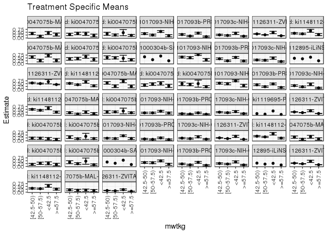

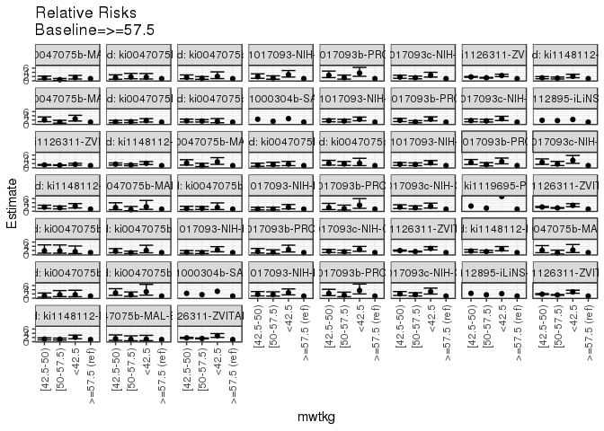

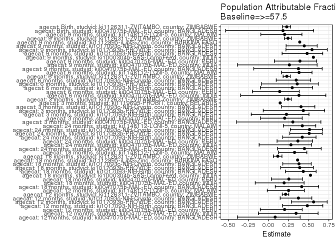

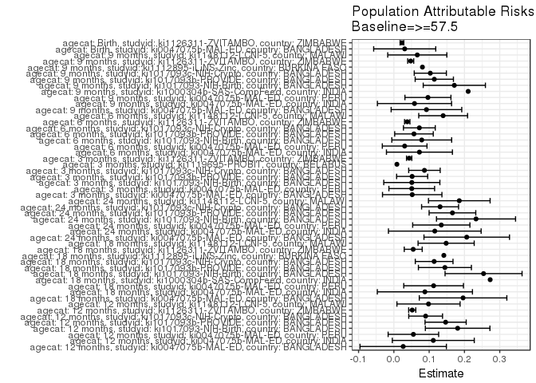

## Results Table

### Parameter: TSM

| agecat | studyid | country | intervention_level | baseline_level | estimate | ci_lower | ci_upper |
| --- | --- | --- | --- | --- | --- | --- | --- |
| Birth | ki0047075b-MAL-ED | BANGLADESH | >=57.5 | NA | 0.1400000 | 0.0436258 | 0.2363742 |
| Birth | ki0047075b-MAL-ED | BANGLADESH | <42.5 | NA | 0.1698113 | 0.0685214 | 0.2711013 |
| Birth | ki0047075b-MAL-ED | BANGLADESH | [42.5-50) | NA | 0.2000000 | 0.1147915 | 0.2852085 |
| Birth | ki0047075b-MAL-ED | BANGLADESH | [50-57.5) | NA | 0.1551724 | 0.0618019 | 0.2485430 |
| Birth | ki1126311-ZVITAMBO | ZIMBABWE | >=57.5 | NA | 0.0783689 | 0.0715450 | 0.0851927 |
| Birth | ki1126311-ZVITAMBO | ZIMBABWE | <42.5 | NA | 0.2191781 | 0.1520714 | 0.2862848 |
| Birth | ki1126311-ZVITAMBO | ZIMBABWE | [42.5-50) | NA | 0.1404899 | 0.1222080 | 0.1587718 |
| Birth | ki1126311-ZVITAMBO | ZIMBABWE | [50-57.5) | NA | 0.1198170 | 0.1090532 | 0.1305808 |
| 3 months | ki0047075b-MAL-ED | BANGLADESH | >=57.5 | NA | 0.1200000 | 0.0297462 | 0.2102538 |
| 3 months | ki0047075b-MAL-ED | BANGLADESH | <42.5 | NA | 0.2545455 | 0.1391921 | 0.3698988 |
| 3 months | ki0047075b-MAL-ED | BANGLADESH | [42.5-50) | NA | 0.2045455 | 0.1200993 | 0.2889916 |
| 3 months | ki0047075b-MAL-ED | BANGLADESH | [50-57.5) | NA | 0.0877193 | 0.0141337 | 0.1613049 |
| 3 months | ki0047075b-MAL-ED | PERU | >=57.5 | NA | 0.2019231 | 0.1246373 | 0.2792088 |
| 3 months | ki0047075b-MAL-ED | PERU | <42.5 | NA | 0.3571429 | 0.1057141 | 0.6085716 |
| 3 months | ki0047075b-MAL-ED | PERU | [42.5-50) | NA | 0.2678571 | 0.1516705 | 0.3840438 |
| 3 months | ki0047075b-MAL-ED | PERU | [50-57.5) | NA | 0.2782609 | 0.1962129 | 0.3603089 |
| 3 months | ki1017093-NIH-Birth | BANGLADESH | >=57.5 | NA | 0.1772152 | 0.0929381 | 0.2614923 |
| 3 months | ki1017093-NIH-Birth | BANGLADESH | <42.5 | NA | 0.3333333 | 0.2585719 | 0.4080947 |
| 3 months | ki1017093-NIH-Birth | BANGLADESH | [42.5-50) | NA | 0.1928934 | 0.1377466 | 0.2480402 |
| 3 months | ki1017093-NIH-Birth | BANGLADESH | [50-57.5) | NA | 0.1914894 | 0.1264861 | 0.2564926 |
| 3 months | ki1017093b-PROVIDE | BANGLADESH | >=57.5 | NA | 0.0677966 | 0.0224020 | 0.1131912 |
| 3 months | ki1017093b-PROVIDE | BANGLADESH | <42.5 | NA | 0.1939394 | 0.1335639 | 0.2543149 |
| 3 months | ki1017093b-PROVIDE | BANGLADESH | [42.5-50) | NA | 0.1167513 | 0.0718742 | 0.1616284 |
| 3 months | ki1017093b-PROVIDE | BANGLADESH | [50-57.5) | NA | 0.0853659 | 0.0425673 | 0.1281644 |
| 3 months | ki1017093c-NIH-Crypto | BANGLADESH | >=57.5 | NA | 0.1276596 | 0.0799245 | 0.1753946 |
| 3 months | ki1017093c-NIH-Crypto | BANGLADESH | <42.5 | NA | 0.3039216 | 0.2146000 | 0.3932431 |
| 3 months | ki1017093c-NIH-Crypto | BANGLADESH | [42.5-50) | NA | 0.2522124 | 0.1955539 | 0.3088708 |
| 3 months | ki1017093c-NIH-Crypto | BANGLADESH | [50-57.5) | NA | 0.2075472 | 0.1529181 | 0.2621762 |
| 3 months | ki1119695-PROBIT | BELARUS | >=57.5 | NA | 0.0509835 | NA | NA |
| 3 months | ki1119695-PROBIT | BELARUS | <42.5 | NA | 0.3571429 | NA | NA |

[output cut: 174 more lines]

### Parameter: E(Y)

| agecat | studyid | country | intervention_level | baseline_level | estimate | ci_lower | ci_upper |
| --- | --- | --- | --- | --- | --- | --- | --- |
| Birth | ki0047075b-MAL-ED | BANGLADESH | NA | NA | 0.1707317 | 0.1236156 | 0.2178478 |
| Birth | ki1126311-ZVITAMBO | ZIMBABWE | NA | NA | 0.1012739 | 0.0956332 | 0.1069146 |
| 3 months | ki0047075b-MAL-ED | BANGLADESH | NA | NA | 0.1720000 | 0.1251265 | 0.2188735 |
| 3 months | ki0047075b-MAL-ED | PERU | NA | NA | 0.2525952 | 0.2024138 | 0.3027765 |
| 3 months | ki1017093-NIH-Birth | BANGLADESH | NA | NA | 0.2280702 | 0.1935943 | 0.2625460 |
| 3 months | ki1017093b-PROVIDE | BANGLADESH | NA | NA | 0.1195652 | 0.0944872 | 0.1446433 |
| 3 months | ki1017093c-NIH-Crypto | BANGLADESH | NA | NA | 0.2142857 | 0.1844587 | 0.2441127 |
| 3 months | ki1119695-PROBIT | BELARUS | NA | NA | 0.0595967 | NA | NA |
| 3 months | ki1126311-ZVITAMBO | ZIMBABWE | NA | NA | 0.1785216 | 0.1704294 | 0.1866138 |
| 6 months | ki0047075b-MAL-ED | INDIA | NA | NA | 0.1914894 | 0.1410749 | 0.2419038 |
| 6 months | ki0047075b-MAL-ED | PERU | NA | NA | 0.2205882 | 0.1712211 | 0.2699554 |
| 6 months | ki1017093-NIH-Birth | BANGLADESH | NA | NA | 0.2681564 | 0.2306532 | 0.3056597 |
| 6 months | ki1017093b-PROVIDE | BANGLADESH | NA | NA | 0.1597938 | 0.1299995 | 0.1895881 |
| 6 months | ki1017093c-NIH-Crypto | BANGLADESH | NA | NA | 0.2097902 | 0.1799252 | 0.2396552 |
| 6 months | ki1126311-ZVITAMBO | ZIMBABWE | NA | NA | 0.1668346 | 0.1586345 | 0.1750346 |
| 6 months | ki1148112-LCNI-5 | MALAWI | NA | NA | 0.3679809 | 0.3352903 | 0.4006715 |
| 9 months | ki0047075b-MAL-ED | BANGLADESH | NA | NA | 0.2478632 | 0.1924231 | 0.3033034 |
| 9 months | ki0047075b-MAL-ED | INDIA | NA | NA | 0.2251082 | 0.1711323 | 0.2790842 |
| 9 months | ki0047075b-MAL-ED | PERU | NA | NA | 0.2470588 | 0.1940178 | 0.3000999 |
| 9 months | ki1000304b-SAS-CompFeed | INDIA | NA | NA | 0.3771712 | NA | NA |
| 9 months | ki1017093-NIH-Birth | BANGLADESH | NA | NA | 0.3570020 | 0.3152562 | 0.3987478 |
| 9 months | ki1017093b-PROVIDE | BANGLADESH | NA | NA | 0.2119205 | 0.1793023 | 0.2445388 |
| 9 months | ki1017093c-NIH-Crypto | BANGLADESH | NA | NA | 0.2322946 | 0.2011222 | 0.2634670 |
| 9 months | ki1112895-iLiNS-Zinc | BURKINA FASO | NA | NA | 0.2083333 | NA | NA |
| 9 months | ki1126311-ZVITAMBO | ZIMBABWE | NA | NA | 0.1970912 | 0.1880006 | 0.2061818 |
| 9 months | ki1148112-LCNI-5 | MALAWI | NA | NA | 0.3323263 | 0.2964166 | 0.3682360 |
| 12 months | ki0047075b-MAL-ED | BANGLADESH | NA | NA | 0.3218884 | 0.2617700 | 0.3820068 |
| 12 months | ki0047075b-MAL-ED | INDIA | NA | NA | 0.3259912 | 0.2648788 | 0.3871036 |
| 12 months | ki0047075b-MAL-ED | PERU | NA | NA | 0.2775510 | 0.2213650 | 0.3337370 |
| 12 months | ki1017093-NIH-Birth | BANGLADESH | NA | NA | 0.3747454 | 0.3318860 | 0.4176049 |
| 12 months | ki1017093b-PROVIDE | BANGLADESH | NA | NA | 0.2616667 | 0.2264673 | 0.2968661 |
| 12 months | ki1017093c-NIH-Crypto | BANGLADESH | NA | NA | 0.2422096 | 0.2105851 | 0.2738341 |
| 12 months | ki1126311-ZVITAMBO | ZIMBABWE | NA | NA | 0.2453178 | 0.2348681 | 0.2557675 |
| 12 months | ki1148112-LCNI-5 | MALAWI | NA | NA | 0.3936000 | 0.3552679 | 0.4319321 |
| 18 months | ki0047075b-MAL-ED | BANGLADESH | NA | NA | 0.4751131 | 0.4091246 | 0.5411016 |
| 18 months | ki0047075b-MAL-ED | INDIA | NA | NA | 0.4537445 | 0.3888366 | 0.5186524 |
| 18 months | ki0047075b-MAL-ED | PERU | NA | NA | 0.4459459 | 0.3804116 | 0.5114803 |
| 18 months | ki1000304b-SAS-CompFeed | INDIA | NA | NA | 0.5228426 | NA | NA |
| 18 months | ki1017093-NIH-Birth | BANGLADESH | NA | NA | 0.5874730 | 0.5425832 | 0.6323628 |
| 18 months | ki1017093b-PROVIDE | BANGLADESH | NA | NA | 0.3731884 | 0.3328048 | 0.4135720 |
| 18 months | ki1017093c-NIH-Crypto | BANGLADESH | NA | NA | 0.3012618 | 0.2655201 | 0.3370036 |
| 18 months | ki1112895-iLiNS-Zinc | BURKINA FASO | NA | NA | 0.3915966 | NA | NA |
| 18 months | ki1126311-ZVITAMBO | ZIMBABWE | NA | NA | 0.4771323 | 0.4527873 | 0.5014772 |
| 18 months | ki1148112-LCNI-5 | MALAWI | NA | NA | 0.4578147 | 0.4214735 | 0.4941558 |
| 24 months | ki0047075b-MAL-ED | BANGLADESH | NA | NA | 0.4622642 | 0.3949918 | 0.5295365 |
| 24 months | ki0047075b-MAL-ED | INDIA | NA | NA | 0.4159292 | 0.3515272 | 0.4803312 |
| 24 months | ki0047075b-MAL-ED | PERU | NA | NA | 0.3681592 | 0.3013164 | 0.4350020 |
| 24 months | ki1017093-NIH-Birth | BANGLADESH | NA | NA | 0.5547786 | 0.5076945 | 0.6018626 |
| 24 months | ki1017093b-PROVIDE | BANGLADESH | NA | NA | 0.3281250 | 0.2897474 | 0.3665026 |
| 24 months | ki1017093c-NIH-Crypto | BANGLADESH | NA | NA | 0.2568093 | 0.2190047 | 0.2946140 |
| 24 months | ki1148112-LCNI-5 | MALAWI | NA | NA | 0.4411765 | 0.4006626 | 0.4816903 |

### Parameter: RR

| agecat | studyid | country | intervention_level | baseline_level | estimate | ci_lower | ci_upper |
| --- | --- | --- | --- | --- | --- | --- | --- |
| Birth | ki0047075b-MAL-ED | BANGLADESH | >=57.5 | >=57.5 | 1.0000000 | 1.0000000 | 1.000000 |
| Birth | ki0047075b-MAL-ED | BANGLADESH | <42.5 | >=57.5 | 1.2129380 | 0.4878157 | 3.015931 |
| Birth | ki0047075b-MAL-ED | BANGLADESH | [42.5-50) | >=57.5 | 1.4285714 | 0.6357904 | 3.209888 |
| Birth | ki0047075b-MAL-ED | BANGLADESH | [50-57.5) | >=57.5 | 1.1083744 | 0.4442330 | 2.765427 |
| Birth | ki1126311-ZVITAMBO | ZIMBABWE | >=57.5 | >=57.5 | 1.0000000 | 1.0000000 | 1.000000 |
| Birth | ki1126311-ZVITAMBO | ZIMBABWE | <42.5 | >=57.5 | 2.7967499 | 2.0342815 | 3.844999 |
| Birth | ki1126311-ZVITAMBO | ZIMBABWE | [42.5-50) | >=57.5 | 1.7926754 | 1.5328590 | 2.096530 |
| Birth | ki1126311-ZVITAMBO | ZIMBABWE | [50-57.5) | >=57.5 | 1.5288853 | 1.3490895 | 1.732643 |
| 3 months | ki0047075b-MAL-ED | BANGLADESH | >=57.5 | >=57.5 | 1.0000000 | 1.0000000 | 1.000000 |
| 3 months | ki0047075b-MAL-ED | BANGLADESH | <42.5 | >=57.5 | 2.1212121 | 0.8815240 | 5.104275 |
| 3 months | ki0047075b-MAL-ED | BANGLADESH | [42.5-50) | >=57.5 | 1.7045455 | 0.7227616 | 4.019963 |
| 3 months | ki0047075b-MAL-ED | BANGLADESH | [50-57.5) | >=57.5 | 0.7309943 | 0.2369227 | 2.255388 |
| 3 months | ki0047075b-MAL-ED | PERU | >=57.5 | >=57.5 | 1.0000000 | 1.0000000 | 1.000000 |
| 3 months | ki0047075b-MAL-ED | PERU | <42.5 | >=57.5 | 1.7687075 | 0.7936834 | 3.941529 |
| 3 months | ki0047075b-MAL-ED | PERU | [42.5-50) | >=57.5 | 1.3265306 | 0.7438469 | 2.365653 |
| 3 months | ki0047075b-MAL-ED | PERU | [50-57.5) | >=57.5 | 1.3780538 | 0.8500307 | 2.234075 |
| 3 months | ki1017093-NIH-Birth | BANGLADESH | >=57.5 | >=57.5 | 1.0000000 | 1.0000000 | 1.000000 |
| 3 months | ki1017093-NIH-Birth | BANGLADESH | <42.5 | >=57.5 | 1.8809524 | 1.1117994 | 3.182212 |
| 3 months | ki1017093-NIH-Birth | BANGLADESH | [42.5-50) | >=57.5 | 1.0884699 | 0.6249334 | 1.895829 |
| 3 months | ki1017093-NIH-Birth | BANGLADESH | [50-57.5) | >=57.5 | 1.0805471 | 0.6024068 | 1.938195 |
| 3 months | ki1017093b-PROVIDE | BANGLADESH | >=57.5 | >=57.5 | 1.0000000 | 1.0000000 | 1.000000 |
| 3 months | ki1017093b-PROVIDE | BANGLADESH | <42.5 | >=57.5 | 2.8606061 | 1.3670170 | 5.986076 |
| 3 months | ki1017093b-PROVIDE | BANGLADESH | [42.5-50) | >=57.5 | 1.7220812 | 0.7957070 | 3.726955 |
| 3 months | ki1017093b-PROVIDE | BANGLADESH | [50-57.5) | >=57.5 | 1.2591463 | 0.5455095 | 2.906365 |
| 3 months | ki1017093c-NIH-Crypto | BANGLADESH | >=57.5 | >=57.5 | 1.0000000 | 1.0000000 | 1.000000 |
| 3 months | ki1017093c-NIH-Crypto | BANGLADESH | <42.5 | >=57.5 | 2.3807190 | 1.4796463 | 3.830525 |
| 3 months | ki1017093c-NIH-Crypto | BANGLADESH | [42.5-50) | >=57.5 | 1.9756637 | 1.2772220 | 3.056044 |
| 3 months | ki1017093c-NIH-Crypto | BANGLADESH | [50-57.5) | >=57.5 | 1.6257862 | 1.0291327 | 2.568357 |
| 3 months | ki1119695-PROBIT | BELARUS | >=57.5 | >=57.5 | 1.0000000 | NA | NA |
| 3 months | ki1119695-PROBIT | BELARUS | <42.5 | >=57.5 | 7.0050618 | NA | NA |

[output cut: 174 more lines]

### Parameter: PAR

| agecat | studyid | country | intervention_level | baseline_level | estimate | ci_lower | ci_upper |
| --- | --- | --- | --- | --- | --- | --- | --- |
| Birth | ki0047075b-MAL-ED | BANGLADESH | >=57.5 | NA | 0.0307317 | -0.0572019 | 0.1186653 |
| Birth | ki1126311-ZVITAMBO | ZIMBABWE | >=57.5 | NA | 0.0229050 | 0.0176244 | 0.0281857 |
| 3 months | ki0047075b-MAL-ED | BANGLADESH | >=57.5 | NA | 0.0520000 | -0.0321699 | 0.1361699 |
| 3 months | ki0047075b-MAL-ED | PERU | >=57.5 | NA | 0.0506721 | -0.0140758 | 0.1154199 |
| 3 months | ki1017093-NIH-Birth | BANGLADESH | >=57.5 | NA | 0.0508550 | -0.0286586 | 0.1303686 |
| 3 months | ki1017093b-PROVIDE | BANGLADESH | >=57.5 | NA | 0.0517686 | 0.0077865 | 0.0957507 |
| 3 months | ki1017093c-NIH-Crypto | BANGLADESH | >=57.5 | NA | 0.0866261 | 0.0420009 | 0.1312513 |
| 3 months | ki1119695-PROBIT | BELARUS | >=57.5 | NA | 0.0086132 | NA | NA |
| 3 months | ki1126311-ZVITAMBO | ZIMBABWE | >=57.5 | NA | 0.0433521 | 0.0358529 | 0.0508514 |
| 6 months | ki0047075b-MAL-ED | INDIA | >=57.5 | NA | 0.0724417 | -0.0210007 | 0.1658842 |
| 6 months | ki0047075b-MAL-ED | PERU | >=57.5 | NA | 0.0305882 | -0.0327192 | 0.0938957 |
| 6 months | ki1017093-NIH-Birth | BANGLADESH | >=57.5 | NA | 0.0789672 | -0.0058010 | 0.1637355 |
| 6 months | ki1017093b-PROVIDE | BANGLADESH | >=57.5 | NA | 0.0569901 | 0.0023540 | 0.1116261 |
| 6 months | ki1017093c-NIH-Crypto | BANGLADESH | >=57.5 | NA | 0.0722241 | 0.0271677 | 0.1172805 |
| 6 months | ki1126311-ZVITAMBO | ZIMBABWE | >=57.5 | NA | 0.0378914 | 0.0302800 | 0.0455028 |
| 6 months | ki1148112-LCNI-5 | MALAWI | >=57.5 | NA | 0.1396344 | 0.0704572 | 0.2088117 |
| 9 months | ki0047075b-MAL-ED | BANGLADESH | >=57.5 | NA | 0.0923077 | -0.0077115 | 0.1923268 |
| 9 months | ki0047075b-MAL-ED | INDIA | >=57.5 | NA | 0.0584416 | -0.0465938 | 0.1634769 |
| 9 months | ki0047075b-MAL-ED | PERU | >=57.5 | NA | 0.0965212 | 0.0313427 | 0.1616997 |
| 9 months | ki1000304b-SAS-CompFeed | INDIA | >=57.5 | NA | 0.2105045 | NA | NA |
| 9 months | ki1017093-NIH-Birth | BANGLADESH | >=57.5 | NA | 0.1712877 | 0.0831862 | 0.2593892 |
| 9 months | ki1017093b-PROVIDE | BANGLADESH | >=57.5 | NA | 0.1145754 | 0.0603861 | 0.1687647 |
| 9 months | ki1017093c-NIH-Crypto | BANGLADESH | >=57.5 | NA | 0.1032624 | 0.0577504 | 0.1487743 |
| 9 months | ki1112895-iLiNS-Zinc | BURKINA FASO | >=57.5 | NA | 0.0808824 | NA | NA |
| 9 months | ki1126311-ZVITAMBO | ZIMBABWE | >=57.5 | NA | 0.0476948 | 0.0391679 | 0.0562218 |
| 9 months | ki1148112-LCNI-5 | MALAWI | >=57.5 | NA | 0.0663688 | -0.0173605 | 0.1500981 |
| 12 months | ki0047075b-MAL-ED | BANGLADESH | >=57.5 | NA | 0.0264339 | -0.0959294 | 0.1487972 |
| 12 months | ki0047075b-MAL-ED | INDIA | >=57.5 | NA | 0.1117055 | -0.0043920 | 0.2278029 |
| 12 months | ki0047075b-MAL-ED | PERU | >=57.5 | NA | 0.0553288 | -0.0162402 | 0.1268978 |
| 12 months | ki1017093-NIH-Birth | BANGLADESH | >=57.5 | NA | 0.1807156 | 0.0892308 | 0.2722003 |
| 12 months | ki1017093b-PROVIDE | BANGLADESH | >=57.5 | NA | 0.1466224 | 0.0883132 | 0.2049317 |
| 12 months | ki1017093c-NIH-Crypto | BANGLADESH | >=57.5 | NA | 0.0900357 | 0.0421662 | 0.1379052 |
| 12 months | ki1126311-ZVITAMBO | ZIMBABWE | >=57.5 | NA | 0.0520256 | 0.0419503 | 0.0621009 |
| 12 months | ki1148112-LCNI-5 | MALAWI | >=57.5 | NA | 0.0981455 | 0.0086591 | 0.1876318 |
| 18 months | ki0047075b-MAL-ED | BANGLADESH | >=57.5 | NA | 0.1960434 | 0.0720123 | 0.3200744 |
| 18 months | ki0047075b-MAL-ED | INDIA | >=57.5 | NA | 0.0878908 | -0.0468669 | 0.2226486 |
| 18 months | ki0047075b-MAL-ED | PERU | >=57.5 | NA | 0.1126126 | 0.0280194 | 0.1972058 |
| 18 months | ki1000304b-SAS-CompFeed | INDIA | >=57.5 | NA | 0.2728426 | NA | NA |
| 18 months | ki1017093-NIH-Birth | BANGLADESH | >=57.5 | NA | 0.2541397 | 0.1450569 | 0.3632224 |
| 18 months | ki1017093b-PROVIDE | BANGLADESH | >=57.5 | NA | 0.1446170 | 0.0695511 | 0.2196828 |
| 18 months | ki1017093c-NIH-Crypto | BANGLADESH | >=57.5 | NA | 0.1141273 | 0.0607062 | 0.1675485 |
| 18 months | ki1112895-iLiNS-Zinc | BURKINA FASO | >=57.5 | NA | 0.1415966 | NA | NA |
| 18 months | ki1126311-ZVITAMBO | ZIMBABWE | >=57.5 | NA | 0.0548525 | 0.0293921 | 0.0803128 |
| 18 months | ki1148112-LCNI-5 | MALAWI | >=57.5 | NA | 0.1480801 | 0.0685577 | 0.2276026 |
| 24 months | ki0047075b-MAL-ED | BANGLADESH | >=57.5 | NA | 0.2064502 | 0.0852828 | 0.3276176 |
| 24 months | ki0047075b-MAL-ED | INDIA | >=57.5 | NA | 0.1159292 | -0.0153498 | 0.2472082 |
| 24 months | ki0047075b-MAL-ED | PERU | >=57.5 | NA | 0.1343930 | 0.0533501 | 0.2154358 |
| 24 months | ki1017093-NIH-Birth | BANGLADESH | >=57.5 | NA | 0.2327447 | 0.1207348 | 0.3447545 |
| 24 months | ki1017093b-PROVIDE | BANGLADESH | >=57.5 | NA | 0.1659628 | 0.0998747 | 0.2320510 |
| 24 months | ki1017093c-NIH-Crypto | BANGLADESH | >=57.5 | NA | 0.1309352 | 0.0785628 | 0.1833076 |
| 24 months | ki1148112-LCNI-5 | MALAWI | >=57.5 | NA | 0.1853625 | 0.0980421 | 0.2726829 |

### Parameter: PAF

| agecat | studyid | country | intervention_level | baseline_level | estimate | ci_lower | ci_upper |
| --- | --- | --- | --- | --- | --- | --- | --- |
| Birth | ki0047075b-MAL-ED | BANGLADESH | >=57.5 | NA | 0.1800000 | -0.5337384 | 0.5615941 |
| Birth | ki1126311-ZVITAMBO | ZIMBABWE | >=57.5 | NA | 0.2261692 | 0.1735894 | 0.2754036 |
| 3 months | ki0047075b-MAL-ED | BANGLADESH | >=57.5 | NA | 0.3023256 | -0.3969869 | 0.6515718 |
| 3 months | ki0047075b-MAL-ED | PERU | >=57.5 | NA | 0.2006059 | -0.0996241 | 0.4188642 |
| 3 months | ki1017093-NIH-Birth | BANGLADESH | >=57.5 | NA | 0.2229796 | -0.2156266 | 0.5033337 |
| 3 months | ki1017093b-PROVIDE | BANGLADESH | >=57.5 | NA | 0.4329738 | -0.0665613 | 0.6985464 |
| 3 months | ki1017093c-NIH-Crypto | BANGLADESH | >=57.5 | NA | 0.4042553 | 0.1623055 | 0.5763232 |
| 3 months | ki1119695-PROBIT | BELARUS | >=57.5 | NA | 0.1445243 | NA | NA |
| 3 months | ki1126311-ZVITAMBO | ZIMBABWE | >=57.5 | NA | 0.2428396 | 0.2006793 | 0.2827762 |
| 6 months | ki0047075b-MAL-ED | INDIA | >=57.5 | NA | 0.3783069 | -0.3471440 | 0.7130950 |
| 6 months | ki0047075b-MAL-ED | PERU | >=57.5 | NA | 0.1386667 | -0.2007227 | 0.3821262 |
| 6 months | ki1017093-NIH-Birth | BANGLADESH | >=57.5 | NA | 0.2944820 | -0.1022984 | 0.5484384 |
| 6 months | ki1017093b-PROVIDE | BANGLADESH | >=57.5 | NA | 0.3566476 | -0.0862704 | 0.6189693 |
| 6 months | ki1017093c-NIH-Crypto | BANGLADESH | >=57.5 | NA | 0.3442681 | 0.0952388 | 0.5247538 |
| 6 months | ki1126311-ZVITAMBO | ZIMBABWE | >=57.5 | NA | 0.2271198 | 0.1811340 | 0.2705230 |
| 6 months | ki1148112-LCNI-5 | MALAWI | >=57.5 | NA | 0.3794611 | 0.1610234 | 0.5410259 |
| 9 months | ki0047075b-MAL-ED | BANGLADESH | >=57.5 | NA | 0.3724138 | -0.1841466 | 0.6673854 |
| 9 months | ki0047075b-MAL-ED | INDIA | >=57.5 | NA | 0.2596154 | -0.3860011 | 0.6044957 |
| 9 months | ki0047075b-MAL-ED | PERU | >=57.5 | NA | 0.3906810 | 0.0729794 | 0.5995023 |
| 9 months | ki1000304b-SAS-CompFeed | INDIA | >=57.5 | NA | 0.5581140 | NA | NA |
| 9 months | ki1017093-NIH-Birth | BANGLADESH | >=57.5 | NA | 0.4797948 | 0.1683518 | 0.6746059 |
| 9 months | ki1017093b-PROVIDE | BANGLADESH | >=57.5 | NA | 0.5406526 | 0.2164604 | 0.7307092 |
| 9 months | ki1017093c-NIH-Crypto | BANGLADESH | >=57.5 | NA | 0.4445319 | 0.2182750 | 0.6053026 |
| 9 months | ki1112895-iLiNS-Zinc | BURKINA FASO | >=57.5 | NA | 0.3882353 | NA | NA |
| 9 months | ki1126311-ZVITAMBO | ZIMBABWE | >=57.5 | NA | 0.2419937 | 0.1984380 | 0.2831826 |
| 9 months | ki1148112-LCNI-5 | MALAWI | >=57.5 | NA | 0.1997099 | -0.0961525 | 0.4157161 |
| 12 months | ki0047075b-MAL-ED | BANGLADESH | >=57.5 | NA | 0.0821212 | -0.3887714 | 0.3933476 |
| 12 months | ki0047075b-MAL-ED | INDIA | >=57.5 | NA | 0.3426641 | -0.1263801 | 0.6163902 |
| 12 months | ki0047075b-MAL-ED | PERU | >=57.5 | NA | 0.1993464 | -0.1031973 | 0.4189197 |
| 12 months | ki1017093-NIH-Birth | BANGLADESH | >=57.5 | NA | 0.4822356 | 0.1741347 | 0.6753950 |
| 12 months | ki1017093b-PROVIDE | BANGLADESH | >=57.5 | NA | 0.5603405 | 0.2848637 | 0.7297012 |
| 12 months | ki1017093c-NIH-Crypto | BANGLADESH | >=57.5 | NA | 0.3717264 | 0.1443868 | 0.5386611 |
| 12 months | ki1126311-ZVITAMBO | ZIMBABWE | >=57.5 | NA | 0.2120744 | 0.1704282 | 0.2516300 |
| 12 months | ki1148112-LCNI-5 | MALAWI | >=57.5 | NA | 0.2493533 | -0.0161414 | 0.4454802 |
| 18 months | ki0047075b-MAL-ED | BANGLADESH | >=57.5 | NA | 0.4126246 | 0.0832941 | 0.6236417 |
| 18 months | ki0047075b-MAL-ED | INDIA | >=57.5 | NA | 0.1937012 | -0.1660020 | 0.4424385 |
| 18 months | ki0047075b-MAL-ED | PERU | >=57.5 | NA | 0.2525253 | 0.0356393 | 0.4206333 |
| 18 months | ki1000304b-SAS-CompFeed | INDIA | >=57.5 | NA | 0.5218447 | NA | NA |
| 18 months | ki1017093-NIH-Birth | BANGLADESH | >=57.5 | NA | 0.4325980 | 0.2104245 | 0.5922556 |
| 18 months | ki1017093b-PROVIDE | BANGLADESH | >=57.5 | NA | 0.3875173 | 0.1510535 | 0.5581170 |
| 18 months | ki1017093c-NIH-Crypto | BANGLADESH | >=57.5 | NA | 0.3788310 | 0.1771433 | 0.5310838 |
| 18 months | ki1112895-iLiNS-Zinc | BURKINA FASO | >=57.5 | NA | 0.3615880 | NA | NA |
| 18 months | ki1126311-ZVITAMBO | ZIMBABWE | >=57.5 | NA | 0.1149628 | 0.0597498 | 0.1669336 |
| 18 months | ki1148112-LCNI-5 | MALAWI | >=57.5 | NA | 0.3234500 | 0.1250649 | 0.4768527 |
| 24 months | ki0047075b-MAL-ED | BANGLADESH | >=57.5 | NA | 0.4466065 | 0.1119606 | 0.6551456 |
| 24 months | ki0047075b-MAL-ED | INDIA | >=57.5 | NA | 0.2787234 | -0.1173678 | 0.5344058 |
| 24 months | ki0047075b-MAL-ED | PERU | >=57.5 | NA | 0.3650404 | 0.1056168 | 0.5492159 |
| 24 months | ki1017093-NIH-Birth | BANGLADESH | >=57.5 | NA | 0.4195271 | 0.1760826 | 0.5910406 |
| 24 months | ki1017093b-PROVIDE | BANGLADESH | >=57.5 | NA | 0.5057915 | 0.2639459 | 0.6681738 |
| 24 months | ki1017093c-NIH-Crypto | BANGLADESH | >=57.5 | NA | 0.5098538 | 0.2709787 | 0.6704578 |
| 24 months | ki1148112-LCNI-5 | MALAWI | >=57.5 | NA | 0.4201550 | 0.1847002 | 0.5876116 |